# New features of AbiPy v0.7

### M. Giantomassi and the AbiPy group

9th international ABINIT developer workshop  
20-22nd May 2019 - Louvain-la-Neuve, Belgium

[figure not shown]

- These slides have been generated using [jupyter](https://jupyter.org), nbconvert and [revealjs](https://revealjs.com/)
- The notebook can be downloaded from this [github repo](https://github.com/gmatteo/abipy_intro_abidev2019)
- To install and configure the software, follow these [installation instructions](https://github.com/abinit/abipy#getting-abipy)

Use the Space key to navigate through all slides.

[figure not shown]

## What is AbiPy?

#### Python package for:

- Generating ABINIT input files automatically
- Post-processing output results (*netcdf* and *text* files)
- Interfacing ABINIT with external tools (e.g. [Vesta](http://jp-minerals.org/vesta/en/))
- Creating and executing workflows (band structures, DFPT, $GW$, BSE…)

#### Why python?

- Easy to use and to learn
- Great support for science ([numpy](http://www.numpy.org/), [scipy](https://www.scipy.org/), [pandas](http://pandas.pydata.org/), [matplotlib](https://matplotlib.org/) …)
- Interactive environments ([ipython](http://ipython.org/), [jupyter notebooks](https://jupyter.org/), GUIs)
- More powerful and flexible than Fortran for implementing the high-level logic needed in modern ab-initio workflows
- [pymatgen](https://github.com/materialsproject) ecosystem and the [materials project database](https://www.materialsproject.org/)…

## How to install AbiPy

Using [pip](https://pypi.org/project/pip/) and python wheels:

```
    pip install abipy --user
```

Using [conda](https://conda.io/en/latest/) (*recommended*):

```
    conda install abipy --channel abinit
```

From the [github repository](https://github.com/abinit/abipy) (*develop mode*):

```
    git clone https://github.com/abinit/abipy.git
    cd abipy
    python setup.py develop
```

For further info see http://abinit.github.io/abipy/installation.html

## AbiPy documentation with galleries of matplotlib examples and workflows

```python
%embed https://abinit.github.io/abipy/index.html
```

[interactive chart not shown]

## Jupyter notebooks with [examples and lessons](https://nbviewer.jupyter.org/github/abinit/abitutorials/blob/master/abitutorials/index.ipynb) inspired by the official tutorials

```python
%embed https://nbviewer.jupyter.org/github/abinit/abitutorials/blob/master/abitutorials/index.ipynb
```

[interactive chart not shown]

[figure not shown]

- Since AbiPy is not restricted to high-throughput, we'll show how to use the terminal to analyze calculations
- Well, a python script would be much more flexible but the goal here is to show that one can replace *grep*, *vim*, *gnuplot* with AbiPy

No perl scripts were harmed in the making of this notebook

## Command line interface

- *abiopen.py* ➝ Open output files inside *ipython* or print/visualize file
- *abistruct.py* ➝ Operate on crystalline structures read from file
- *abicomp.py* ➝ Compare multiple files (i.e. convergence studies)
- *abiview.py* ➝ Quick visualization of output files
- *abinp.py* ➝ Generate input files for typical calculations

### Documentation

- `abistruct.py --help` for manpage
- `abistruct.py COMMAND --help` for help about `COMMAND`

  HTML documentation available at http://abinit.github.io/abipy/scripts/index.html

### Examples

```
abistruct.py spglib si_scf_GSR.nc
abistruct.py convert si_scf_GSR.nc -f cif
abiopen.py si_scf_GSR.nc --print
```

### and many more...

#### Print results stored in FILE (more than 45 file extensions supported)

```python
!abiopen.py si_scf_GSR.nc --print
```

[output not shown]

#### To produce a predefined set of matplotlib figures, use:

```
abiopen.py mgb2_kpath_FATBANDS.nc --expose --seaborn
```

[figure not shown]

#### Replace *--expose* with *--notebook* to generate a jupyter notebook with predefined python code

#### *abiopen.py* supports output files (note *abo* extension):

```python
!abiopen.py gs_dfpt.abo -p
```

```
ndtset: 3, completed: True
Full Formula (C2)
Reduced Formula: C
abc   :   2.508336   2.508336   2.508336
angles:  60.000000  60.000000  60.000000
Sites (2)
  #  SP       a     b     c
---  ----  ----  ----  ----
  0  C     0     0     0
  1  C     0.25  0.25  0.25

Abinit Spacegroup: spgid: 227, num_spatial_symmetries: 48, has_timerev: True, symmorphic: True

========================= Dimensions of calculation =========================
         intxc  ionmov  iscf  lmnmax  lnmax  mgfft  mpssoang  mqgrid  natom  \
dataset
1            0     0.0     7       1      1     24         2    3001      2
2            0     NaN     7       1      1     24         2    3001      2
3            0     NaN     7       1      1     24         2    3001      2

         nloc_mem  nspden  nspinor  nsppol  nsym  n1xccc  ntypat  occopt  \
dataset
1               1       1        1       1    48    2501       1       1
2               1       1        1       1    48    2501       1       1
3               1       1        1       1    48    2501       1       1

         xclevel  mband  mffmem  mkmem  mpw   nfft  nkpt  mem_per_proc_mb  \
dataset
1              1      4       1      8  609  13824     8            4.791
2              1      4       1     64  609  13824    64           11.529
3              1      4       1     64  609  13824    64           12.285

         wfk_size_mb  denpot_size_mb spg_symbol  spg_number  \
dataset
1              0.299           0.107      Fd-3m         227
2              2.381           0.107      Fd-3m         227
3              2.381           0.107      Fd-3m         227

                                bravais
dataset
1        Bravais cF (face-center cubic)
2        Bravais cF (face-center cubic)
3        Bravais cF (face-center cubic)
```

#### and log files as well:

```python
!abiopen.py run.log -p
```

```
Events found in /Users/gmatteo/talks/abipy_intro_abidev2019/run.log

[1] <AbinitComment at m_dtfil.F90:1082>
    Output file: run.abo already exists.

[2] <AbinitComment at m_dtfil.F90:1106>
    Renaming old run.abo to run.abo0001

[3] <AbinitWarning at m_mpinfo.F90:2295>
    nkpt*nsppol (29) is not a multiple of nproc_kpt (2)
    The k-point parallelisation is not efficient.

[4] <AbinitWarning at m_mpinfo.F90:2295>
    nkpt*nsppol (29) is not a multiple of nproc_kpt (2)
    The k-point parallelisation is not efficient.

[5] <AbinitComment at m_xgScalapack.F90:237>
    xgScalapack in auto mode

[6] <AbinitWarning at m_phonons.F90:3215>
    ph_nqpath <= 0 or ph_ndivsm <= 0. Phonon bands won't be produced. returning

[7] <AbinitComment at m_xgScalapack.F90:237>
    xgScalapack in auto mode

[8] <AbinitWarning at m_phonons.F90:3215>
    ph_nqpath <= 0 or ph_ndivsm <= 0. Phonon bands won't be produced. returning

num_errors: 0, num_warnings: 4, num_comments: 4, completed: True
```

#### If you are still using perl scripts to extract data from the main output file, check this out:

```
abiopen.py gs_dfpt.abo --expose --seaborn
```

[figure not shown]

#### The introduction of Yaml documents in the main output (*cfr.* Theo's talk) will facilitate the implementation of new post-processing tools...

[figure not shown]

#### It works with any file providing a structure object (*.nc*, .abi, *.cif* …)

#### Convert structure from netcdf format to CIF (*abivars*, *xsf*, *poscar*, *qe*, *siesta*, *wannier90*, *json*)

```python
!abistruct.py convert si_scf_GSR.nc -f cif
```

```
# generated using pymatgen
data_Si
_symmetry_space_group_name_H-M   'P 1'
_cell_length_a   3.86697464
_cell_length_b   3.86697464
_cell_length_c   3.86697464
_cell_angle_alpha   60.00000000
_cell_angle_beta   60.00000000
_cell_angle_gamma   60.00000000
_symmetry_Int_Tables_number   1
_chemical_formula_structural   Si
_chemical_formula_sum   Si2
_cell_volume   40.88829228
_cell_formula_units_Z   2
loop_
 _symmetry_equiv_pos_site_id
 _symmetry_equiv_pos_as_xyz
  1  'x, y, z'
loop_
 _atom_site_type_symbol
 _atom_site_label
 _atom_site_symmetry_multiplicity
 _atom_site_fract_x
 _atom_site_fract_y
 _atom_site_fract_z
 _atom_site_occupancy
  Si  Si1  1  0.000000  0.000000  0.000000  1
  Si  Si2  1  0.250000  0.250000  0.250000  1
```

#### Are you still using *cut3d* to export the structure in a format that other applications can understand?

```
abistruct.py visualize run_si02.abi
```

[figure not shown]

#### Supports also *ovito*, *xcrysden*, *vtk*, *mayavi*, *matplotlib* (Use *--application* option)

#### Connect to the materials project database to find similar structures.

```python
!abistruct.py mp_match si_scf_GSR.nc
```

```
# Found 1 structures in Materials Project database (use `verbose` to get further info)


########################## abivars input for mp-149 ##########################
# Full Formula (Si2)
# Reduced Formula: Si
# abc   :   3.866975   3.866975   3.866975
# angles:  60.000000  60.000000  60.000000
#
# Spglib space group info (magnetic symmetries not taken into account).
# Spacegroup: Fd-3m (227), Hall: F 4d 2 3 -1d, Abinit spg_number: None
# Crystal_system: cubic, Lattice_type: cubic, Point_group: m-3m
#
#   Idx  Symbol    Reduced_Coords              Wyckoff      EqIdx
# -----  --------  --------------------------  ---------  -------
#     0  Si        +0.87500 +0.87500 +0.87500  (2a)             0
#     1  Si        +0.12500 +0.12500 +0.12500  (2a)             0

 natom 2
 ntypat 1
 typat 1 1
 znucl 14
 xred
    0.8750000000    0.8750000000    0.8750000000
    0.1250000000    0.1250000000    0.1250000000
 acell    1.0    1.0    1.0
 rprim
    6.3285005334    0.0000000000    3.6537614829
    2.1095001778    5.9665675247    3.6537614829
    0.0000000000    0.0000000000    7.3075229659
```

#### To search by chemical system or formula (no FILE required)

```python
!abistruct.py mp_search LiF
```

```
# Found 3 structures in Materials Project database (use `verbose` to get further info)

           pretty_formula  e_above_hull  energy_per_atom  \
mp-1185301            LiF      0.007565        -4.837577
mp-1009009            LiF      0.273111        -4.572031
mp-1138               LiF      0.000000        -4.845142

            formation_energy_per_atom  nsites     volume spacegroup.symbol  \
mp-1185301                  -3.173315       4  42.223600            P6_3mc
mp-1009009                  -2.907769       2  16.768040             Pm-3m
mp-1138                     -3.180880       2  17.022154             Fm-3m

            spacegroup.number  band_gap  total_magnetization material_id  \
mp-1185301                186    7.4778         0.000000e+00  mp-1185301
mp-1009009                221    7.5593         0.000000e+00  mp-1009009
mp-1138                   225    8.7161         9.000000e-07     mp-1138

                   a         b         c  alpha  beta       gamma
mp-1185301  3.139544  3.139544  4.946425   90.0  90.0  120.000008
mp-1009009  2.559533  2.559533  2.559533   90.0  90.0   90.000000
mp-1138     2.887419  2.887419  2.887419   60.0  60.0   60.000000


######################## abivars input for mp-1185301 ########################
# Full Formula (Li2 F2)
# Reduced Formula: LiF
# abc   :   3.139544   3.139544   4.946425
# angles:  90.000000  90.000000 120.000008
#
# Spglib space group info (magnetic symmetries not taken into account).
# Spacegroup: P6_3mc (186), Hall: P 6c -2c, Abinit spg_number: None
# Crystal_system: hexagonal, Lattice_type: hexagonal, Point_group: 6mm
#
#   Idx  Symbol    Reduced_Coords              Wyckoff      EqIdx
# -----  --------  --------------------------  ---------  -------
#     0  Li        +0.00000 +0.00000 +0.38019  (2b)             0
#     1  Li        +0.33333 +0.66667 +0.88019  (2b)             0
#     2  F         +0.00000 +0.00000 +0.99481  (2b)             2
#     3  F         +0.33333 +0.66667 +0.49481  (2b)             2

```

[output cut: 63 more lines]

```
#     0  Li        +0.00000 +0.00000 +0.00000  (1a)             0
#     1  F         +0.50000 +0.50000 +0.50000  (1b)             1

 natom 2
 ntypat 2
 typat 1 2
 znucl 3 9
 xred
    0.0000000000    0.0000000000    0.0000000000
    0.5000000000    0.5000000000    0.5000000000
 acell    1.0    1.0    1.0
 rprim
    4.7254082787    0.0000000000    2.7282157318
    1.5751360851    4.4551576322    2.7282157281
    0.0000000000    0.0000000000    5.4564314785
```

[figure not shown]

#### Need to call *anaddb* to compute and visualize ph-bands and DOS from DDB?

```
abiview.py ddb ZnSe_hex_qpt_DDB --seaborn
```

[figure not shown]

#### Add --phononwebsite to visualize data on the [phononwebsite](http://henriquemiranda.github.io/phononwebsite/) by Henrique

#### Need to get a quick look at the Fermi surface?

```
abiview.py fs mgb2_kmesh181818_FATBANDS.nc
```

[figure not shown]

#### Use *-a xsf* for Xcrysden or *-a mayavi* for Mayavi backend

[figure not shown]

#### To compare multiple structures:

```python
!abicomp.py structure *.cif si_nscf_GSR.nc `find . -name *_DDB`
```

```
Spglib options: symprec= 0.001 angle_tolerance= 5.0
Lattice parameters:
                  formula  natom  alpha  beta  gamma         a         b  \
AlAs.cif          Al1 As1      2   60.0  60.0   60.0  3.970101  3.970101
si.cif                Si2      2   60.0  60.0   60.0  3.866975  3.866975
si_nscf_GSR.nc        Si2      2   60.0  60.0   60.0  3.866975  3.866975
ZnSe_hex_qpt_DDB  Zn2 Se2      4   90.0  90.0  120.0  4.050187  4.050187

                         c     volume abispg_num spglib_symb  spglib_num  \
AlAs.cif          3.970101  44.247584       None       F-43m         216
si.cif            3.866975  40.888292       None       Fd-3m         227
si_nscf_GSR.nc    3.866975  40.888292        227       Fd-3m         227
ZnSe_hex_qpt_DDB  6.652328  94.504936          0      P6_3mc         186

                 spglib_lattice_type
AlAs.cif                       cubic
si.cif                         cubic
si_nscf_GSR.nc                 cubic
ZnSe_hex_qpt_DDB           hexagonal
```

#### Note shell wildcard characters and Unix `find` inside backticks (bash rocks!)

#### Using *ElectronBandsPlotter* to visualize multiple band structures:

```
abicomp.py ebands *_GSR.nc
```

[figure not shown]

## Bash is handy but python is more flexible

##### Let's use the *DdbRobot* to compare phonons obtained with different ${\bf k}$-meshes and smearing values:

```python
paths = [
    "mgb2_888k_0.01tsmear_DDB",
    "mgb2_888k_0.04tsmear_DDB",
    "mgb2_121212k_0.01tsmear_DDB",
    "mgb2_121212k_0.04tsmear_DDB",
]

paths = [os.path.join(abidata.dirpath, "refs", "mgb2_phonons_nkpt_tsmear", f)
         for f in paths]

robot = abilab.DdbRobot()
for i, path in enumerate(paths):
    robot.add_file(path, path)
```

```python
# Define function to change labels:
func = lambda ddb: "nkpt: %s, tsmear: %.2f" % (
    ddb.header["nkpt"], ddb.header["tsmear"])

robot.remap_labels(func)
robot
```

0. nkpt: 256, tsmear: 0.01

1. nkpt: 256, tsmear: 0.04

2. nkpt: 864, tsmear: 0.01

3. nkpt: 864, tsmear: 0.04

#### Now we can build a dataframe with the most important parameters:

```python
robot.get_params_dataframe()
```

|  | nkpt | nsppol | ecut | tsmear | occopt | ixc | nband | usepaw |
| --- | --- | --- | --- | --- | --- | --- | --- | --- |
| nkpt: 256, tsmear: 0.01 | 256 | 1 | 35.0 | 0.01 | 4 | 1 | 8 | 0 |
| nkpt: 256, tsmear: 0.04 | 256 | 1 | 35.0 | 0.04 | 4 | 1 | 8 | 0 |
| nkpt: 864, tsmear: 0.01 | 864 | 1 | 35.0 | 0.01 | 4 | 1 | 8 | 0 |
| nkpt: 864, tsmear: 0.04 | 864 | 1 | 35.0 | 0.04 | 4 | 1 | 8 | 0 |

#### and check that all DDBs have been computed with the same crystalline structure:

```python
robot.get_lattice_dataframe()
```

|  | formula | natom | alpha | beta | gamma | a | b | c | volume | abispg_num | spglib_symb | spglib_num | spglib_lattice_type |
| --- | --- | --- | --- | --- | --- | --- | --- | --- | --- | --- | --- | --- | --- |
| nkpt: 256, tsmear: 0.01 | Mg1 B2 | 3 | 90.0 | 90.0 | 120.0 | 3.086 | 3.086 | 3.523 | 29.055953 | 0 | P6/mmm | 191 | hexagonal |
| nkpt: 256, tsmear: 0.04 | Mg1 B2 | 3 | 90.0 | 90.0 | 120.0 | 3.086 | 3.086 | 3.523 | 29.055953 | 0 | P6/mmm | 191 | hexagonal |
| nkpt: 864, tsmear: 0.01 | Mg1 B2 | 3 | 90.0 | 90.0 | 120.0 | 3.086 | 3.086 | 3.523 | 29.055953 | 0 | P6/mmm | 191 | hexagonal |
| nkpt: 864, tsmear: 0.04 | Mg1 B2 | 3 | 90.0 | 90.0 | 120.0 | 3.086 | 3.086 | 3.523 | 29.055953 | 0 | P6/mmm | 191 | hexagonal |

#### To analyze the effect of k-sampling/smearing on the vibrational properties:

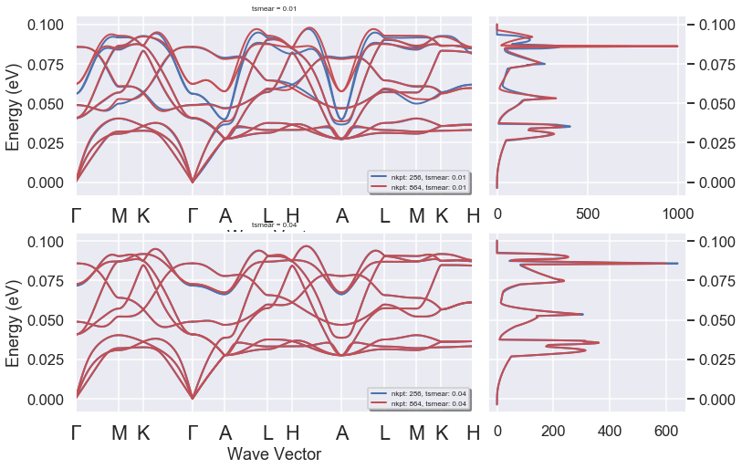

```python
# Invoke anaddb and store results
r = robot.anaget_phonon_plotters(nqsmall=2)

r.phbands_plotter.gridplot_with_hue("tsmear", with_dos=True);
```

[figure not shown]

### Input file for band structure calculation + DOS

1. GS run to get the density
2. NSCF run along high-symmetry **k**-path
3. NSCF run with **k**-mesh to compute the DOS

```python
multi = abilab.ebands_input(structure="si.cif",
                            pseudos="14si.pspnc",
                            ecut=8,
                            spin_mode="unpolarized",
                            smearing=None,
                            dos_kppa=5000)

multi.get_vars_dataframe("kptopt", "iscf", "ngkpt")
```

|  | kptopt | iscf | ngkpt |
| --- | --- | --- | --- |
| dataset 0 | 1 | None | [8, 8, 8] |
| dataset 1 | -11 | -2 | None |
| dataset 2 | 1 | -2 | [14, 14, 14] |

#### To build an input for SCF+NSCF run with (relaxed) structure from the materials project database:

```
    abinp.py ebands mp-149
```

#### *abinp.py* is handy for generating input files quickly but it cannot compete with the flexibility of the python interface:

```python
def make_scf_input(ecut=2, ngkpt=(4, 4, 4)):
    """
    Generate an `AbinitInput` to perform GS calculation for AlAs.

    Args:
        ecut: Cutoff energy in Ha.
        ngkpt: k-mesh divisions

    Return:
        `AbinitInput` object
    """
    gs_inp = abilab.AbinitInput(structure="AlAs.cif",
                                pseudos=["13al.pspnc", "33as.pspnc"])

    # Set the value of the Abinit variables needed for GS runs.
    gs_inp.set_vars(
        nband=4,
        ecut=ecut,
        ngkpt=ngkpt,
        nshiftk=4,
        shiftk=[0.0, 0.0, 0.5,   # This gives the usual fcc Monkhorst-Pack grid
                0.0, 0.5, 0.0,
                0.5, 0.0, 0.0,
                0.5, 0.5, 0.5],
        tolvrs=1.0e-10,
    )

    return gs_inp
```

#### Inside the notebook, one gets the HTML representation with links to the documentation:

```python
make_scf_input()
```

############################################################################################  
# SECTION: basic  
############################################################################################  
nband 4  
ecut 2  
ngkpt 4 4 4  
nshiftk 4  
shiftk  
0.0 0.0 0.5  
0.0 0.5 0.0  
0.5 0.0 0.0  
0.5 0.5 0.5  
tolvrs 1e-10  
############################################################################################  
# STRUCTURE  
############################################################################################  
natom 2  
ntypat 2  
typat 1 2  
znucl 13 33  
xred  
0.0000000000 0.0000000000 0.0000000000  
0.2500000000 0.2500000000 0.2500000000  
acell 1.0 1.0 1.0  
rprim  
6.4972715500 0.0000000000 3.7512014784  
2.1657571833 6.1256863630 3.7512014784  
0.0000000000 0.0000000000 7.5024029568

#### Moreover, from an `AbiniInput` one can easily build more complicate workflows:

```python
def build_flow_alas_phonons():
    """
    Build and return a Flow to compute the dynamical matrix on a (2, 2, 2) qmesh
    as well as DDK and Born effective charges.
    The final DDB with all perturbations will be merged automatically and placed
    in the Flow `outdir` directory.
    """
    from abipy import flowtk
    scf_input = make_scf_input(ecut=6, ngkpt=(4, 4, 4))
    return flowtk.PhononFlow.from_scf_input("flow_alas_phonons", scf_input,
                                            ph_ngqpt=(2, 2, 2), with_becs=True)
```

##### Abipy will call Abinit to get the list of DFPT perturbations and…

```python
flow_phbands = build_flow_alas_phonons()
flow_phbands.get_graphviz()
```

[figure not shown]

## Future developments

### Post-processing tools

- Support for more *netcdf* files
- More post-processing tools for MD calculations
- More converters and interfaces for third-party applications
- Integrate AbiPy with jupyterlab to create a flexible graphical enviroment for Abinit exposing (part) of the python API
- Explore web-based technologies for data analysis and visualization ([plotly](https://plot.ly/), [dash](https://plot.ly/products/dash/))
- Develop toolkit to build web apps powered by AbiPy and pymatgen to disseminate scientific results.

## Continuous Integration

- Use AbiPy programmatic interface to implement:
  - Validation of parallel algorithms for np in range(1, N)
  - Stress testing
  - Benchmarks